# Exploring Kalman Filters

## Experimenting with Kalman Filter from Exercises 3-1 and 3-2

This article experiments with the Kalman filter from exercise 3-2 (page 81) from *Probabilistic Robotics* by Thrun, Bergard, and Fox. Exercise 3-2 is a continuation of exercise 3-1. Please read the articles on exercises 3-1 and 3-2 before reading this article.

- Back to List of PR Notebooks
- [Back to Projects List](http://irwinsnet.github.io)

## 1. Defining the Kalman Filter

First I'll define the matrices that comprise the Kalman filter. For easy reference, here are the Kalman filter equations:

$$ \tag{1} \overline{\vec \mu}_t = \mathbf{A}_t \vec \mu_{t-1} + \mathbf{B}_t \vec u_t$$

$$ \tag{2} \overline{\mathbf{\Sigma}}_t = \mathbf A_t \mathbf \Sigma_{t-1} \mathbf A_t^T + \mathbf R $$

$$ \tag{3} \mathbf{K_t} = \mathbf{\overline{\Sigma}}_t \mathbf{{C_t}^T} (\mathbf{C_t} \mathbf{\overline{\Sigma}}_t \mathbf{{C_t}^T} + \mathbf{Q_t})^{-1} $$

$$ \tag{4} \vec \mu_t = \overline{\vec \mu}_t + \mathbf{K}_t (\vec z_t - \mathbf{C}_t \overline{\vec \mu}_t) $$

$$ \tag{6} \mathbf{\Sigma}_t = (\mathbf{I} - \mathbf{K}_t \mathbf{C}) \mathbf{\overline\Sigma}_t $$

```python
# Matrices that are used as inputs to the Kalman filter
import sympy

# Required for nice-looking output
from IPython.display import display
sympy.init_printing(use_latex=True)

# State transition matrix A: equations #1 and #2
A = sympy.Matrix([[1, 1],[0, 1]])

# Transition noise matrix R: : equations #1 and #2
R = sympy.Matrix([[1/4, 1/2], [1/2, 1]])

# We can ignore the control matrix B because no controls are used in this
#   exercise (i.e., all elements of vector u always equal 0).

# Measurement matrix C: equations #3, #4, and #6
C = sympy.Matrix([[1, 0]])

# Measurement noise matrix Q: equation #3
Q = sympy.Matrix([[10]])

# Identity matrix I: equation #6
I = sympy.Matrix([[1, 0], [0, 1]])

display("A", A, "R", R, "C", C, "Q", Q, "I", I)
```

[output not shown]

## 2. Defining Python Functions

Next I'll define the Python functions that will be used in subsequent calculations.

### Functions for Calculating Beliefs (Means and Covariance Matrices)

```python
# Equation (1)
def mean_prediction(mu_1):
    return A * mu_1


# Equation (2)
def covariance_prediction(Sigma_1):
    return A * Sigma_1 * A.T + R


# Equation (3)
def kalman_gain(Sigma_pred):
    C = sympy.Matrix([[1, 0]])
    return Sigma_pred * C.T * (C * Sigma_pred * C.T + Q).inv()


# Equation (4)
def mean_post(mu_pred, z, K):
    z_matrix =sympy.Matrix([[z]])
    return mu_pred + K * (z_matrix - C * mu_pred)


# Equation (5)
def covariance_post(Sigma_pred, K):
    I = sympy.Matrix([[1, 0], [0, 1]])
    return (I - K * C) * Sigma_pred


# Function that combines equations (1) and (2)
def prediction(belief):
    return {"mu": mean_prediction(belief["mu"]),
            "Sigma": covariance_prediction(belief["Sigma"])}


# Function that combines equations (3) - (5)
def measurement(belief, z):
    K = kalman_gain(belief["Sigma"])
    return {"mu": mean_post(belief["mu"], z, K),
            "Sigma": covariance_post(belief["Sigma"], K)}

# Combine everything
def next_belief(belief, z):
    pred = prediction(belief)
    return measurement(pred, z)
```

### Function for Eigenvalues and Eigenvectors

```python
import math
import matplotlib
matplotlib.use('nbAgg')
import matplotlib.pyplot as plt
import matplotlib.patches as mpatches
import matplotlib.lines as lines
# import numpy as np

def get_eigen_data(matrix):
    """Extracts eigenvalues and eigenvectors from covariance matrix.
    """
    eigenvects = matrix.eigenvects()
    if eigenvects[0][0] > eigenvects[1][0]:
        idx_max = 0
        idx_min = 1
    else:
        idx_max = 1
        idx_min = 0

    return {"eigvec_major": list(eigenvects[idx_max][2][0]),
            "eigvec_minor": list(eigenvects[idx_min][2][0]),
            "eigval_major": eigenvects[idx_max][0],
            "eigval_minor": eigenvects[idx_min][0],
            "theta_major": math.atan(eigenvects[idx_max][2][0][1]/
                               eigenvects[idx_max][2][0][0])*180/math.pi,
            "theta_minor": math.atan(eigenvects[idx_min][2][0][1]/
                               eigenvects[idx_min][2][0][0])*180/math.pi,
           }
```

### Function for Plotting Beliefs

```python
def plot_ellipses(beliefs, colors, title, scale = 10):
    """Plots a series of uncertainty ellipses.

    Args:
        data: [(mu0, cov0), (mu1, cov1), ...]
    """
    plt.close()

    # Setup plot
    fig = plt.figure()
    ax = fig.add_subplot(111)

    # Set plot size
    ax.set_xlim(-scale, scale)
    ax.set_ylim(-scale, scale)
    ax.set_aspect('equal', adjustable='datalim')

    # Plot ellipses
    for belief in enumerate(beliefs):
        col_idx = belief[0]
        mu = belief[1]["mu"]
        eig = get_eigen_data(belief[1]["Sigma"])
        ell = mpatches.Ellipse((mu[0], mu[1]),
                               math.sqrt(eig["eigval_major"]*5.992)*2,
                               math.sqrt(eig["eigval_minor"]*5.992)*2,
                               eig["theta_major"], fill=False,
                               edgecolor=colors[col_idx])
        ax.add_patch(ell)

    # Plot ellipse centers
    x = [belief["mu"][0] for belief in beliefs]
    y = [belief["mu"][1] for belief in beliefs]
    plt.plot(x, y, ".k-")

    # Add title and stuff
    plt.grid()
    plt.title(title)
    plt.xlabel("Position")
    plt.ylabel("Velocity")
    plt.show()
```

## 3. Effect of Multiple Measurements on Precision

In Article #3 we calculated the belief at time 5 with only a single measurement at time 5. What happens if we have measurements at earlier times? Does that decrease the size of our error ellipse?

First, I'll calculate the error ellipse at time $t = 5$ with measurements at time 2 ($z = 1$) and time 5 ($z = 5$) and compare that to the error ellipse that occurs if there is only the one measurement at $t = 5$.

```python
# Belief at time t = 0
bel_0 = {"mu": sympy.Matrix([[0], [0]]),
           "Sigma": sympy.Matrix([[0, 0], [0, 0]])}
```

Since there is no measurement at time t = 1, no measurement step is required and we only need to do the prediction step to get the belief at time $t = 1$.

```python
bel_1 = prediction(bel_0)
display(bel_1["mu"], bel_1["Sigma"])
```

$$\left[\begin{matrix}0\\0\end{matrix}\right]$$

$$\left[\begin{matrix}0.25 & 0.5\\0.5 & 1\end{matrix}\right]$$

There is a measurement at time $t = 2$:

```python
pred_2 = prediction(bel_1)
bel_2 = next_belief(bel_1, 1)
display(bel_2["mu"], bel_2["Sigma"])
```

$$\left[\begin{matrix}0.2\\0.16\end{matrix}\right]$$

$$\left[\begin{matrix}2.0 & 1.6\\1.6 & 1.68\end{matrix}\right]$$

##### Effect of Measurement at Time 2

A plot of the 95% error ellipses for the prediction (before measurement, red) and measurement update(blue).

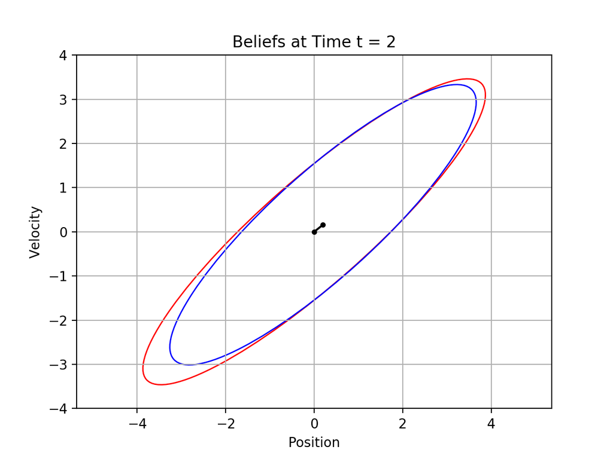

```python
plot_ellipses([pred_2, bel_2], ["r", "b"], "Beliefs at Time t = 2", 4)
```

Prior to the measurement, the belief is centered at (0, 0). The effect of the measurement is to shift both $x$ and $\dot x$ in the positive direction, and to slightly shrink the covariance matrix. Even though our measurement had the robot at $x = 1$, the Kalman algorithm believes the robot is at $x = 0.2$. We can see that due to the size of the measurement uncertainty, the algorithm assigns a higher weight to the prediction.

But what if the measurement uncertainty were smaller? Let's see what would happen if we shrink the measurement covariance from 10 down to 1.

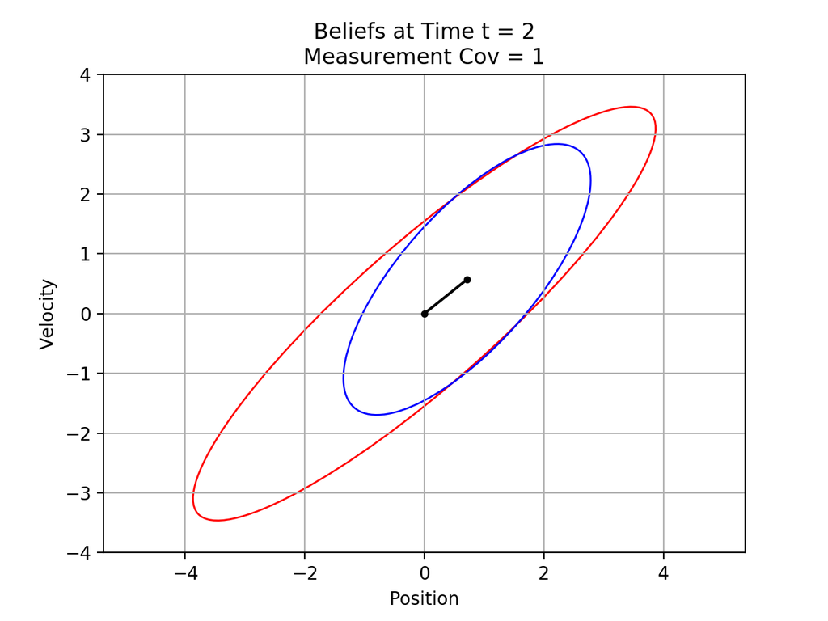

```python
# Shrink covariance of measurement from 10 to 1
Q = sympy.Matrix([[1]])

# Recalculate measurement update
bel_2_c1 = next_belief(bel_1, 1)
title = "Beliefs at Time t = 2\nMeasurement Cov = 1"
plot_ellipses([pred_2, bel_2_c1], ["r", "b"], title , 4)

# Restore original covariance
Q = sympy.Matrix([[10]])
```

*Interesting!* The Kalman filter has assigned greater weight to the measurement. This results in a greater positive shift in velocity and position and a smaller error ellipse.

#### Time $t = 5$

There are no measurements for times 3 and 4 so the beliefs are equal to the predictions.

```python
# Create Sigma_5
bel_3 = prediction(bel_2)
bel_4 = prediction(bel_3)
display(bel_4["mu"], bel_4["Sigma"])
```

$$\left[\begin{matrix}0.52\\0.16\end{matrix}\right]$$

$$\left[\begin{matrix}17.62 & 6.96\\6.96 & 3.68\end{matrix}\right]$$

Incorporating the measurement of $x = 5$ at time $t = 5$:

```python
pred_5 = prediction(bel_4)
bel_5 = next_belief(bel_4, 5)
display(bel_5["mu"], bel_5["Sigma"])
```

$$\left[\begin{matrix}4.0499230261711\\1.21838574884539\end{matrix}\right]$$

$$\left[\begin{matrix}7.80074774576644 & 2.44996701121619\\2.44996701121619 & 1.95073674950517\end{matrix}\right]$$

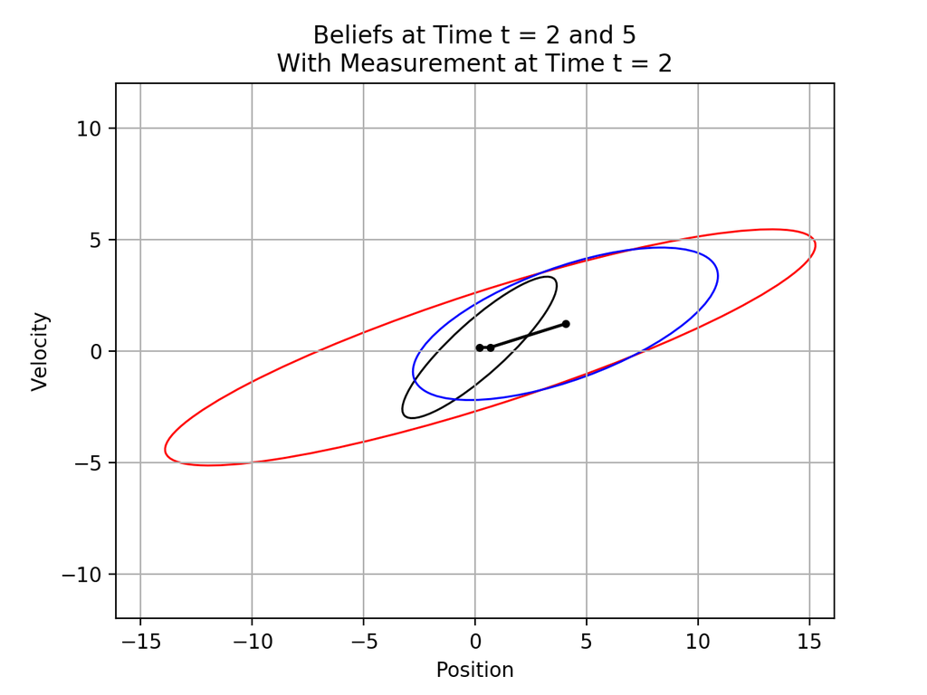

```python
title = "Beliefs at Time t = 2 and 5\nWith Measurement at Time t = 2"
plot_ellipses([bel_2, pred_5, bel_5], ["k", "r", "b"], title, 12)
```

There are a couple interesting things going on here:

1. The black ellipse represents the post-measurement belief at time $t = 2$. It's centered at about (0.2, 0.16) representing the measurement ($x = 1$) taken at time 2. The red ellipse represents the pre-measurement prediction at time $t = 5$. The horizontal black line tells us that the Kalman filter has shifted expected position to the right, event without a measurement. This shows that the filter is able to account for the believed velocity at time $t = 2$ ($\dot x = 0.16$) and incorporate it into subsequent beliefs.
2. The blue ellipse represents the measurement update at time $t = 5$. The measurement has resulted in significantly shrinking the uncertainty. Also, the believed position is now at about 4.05, not far from the measurement of 5. In this instance the filter weighted the measurement more than the prediction (because the prediction had much greater uncertainty than the measurement).

Now let's see what the belief at time $t = 5$ would be with no measurement at time $t = 2$.

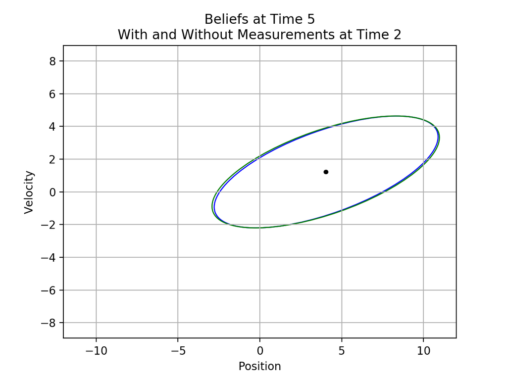

```python
bel_3_nm = prediction(pred_2)
bel_4_nm = prediction(bel_3_nm)
bel_5_nm = next_belief(bel_4_nm, 5)
title = "Beliefs at Time 5\nWith and Without Measurements at Time 2"
plot_ellipses([bel_5, bel_5_nm], ["b", "g"], title, 12)
```

Hmmm. Not much difference. This must be because the measurement covariance is so high, that there was little difference between the prediction and update at time 2. Let's see what happens if we recalculate with measurement covariance = 1.

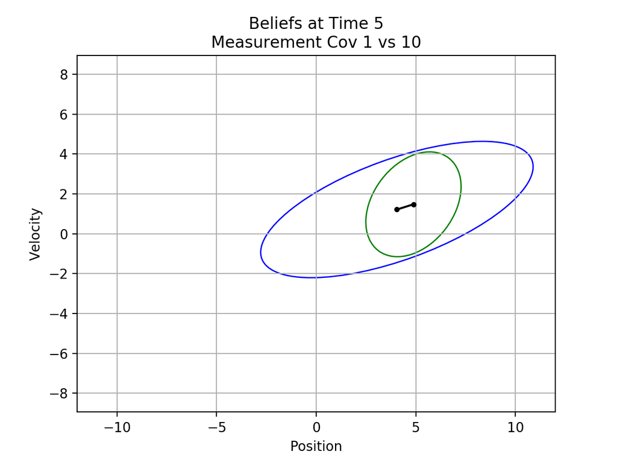

```python
# Shrink covariance of measurement from 10 to 1
Q = sympy.Matrix([[1]])

bel_3_c1 = prediction(bel_2_c1)
bel_4_c1 = prediction(bel_3_c1)
bel_5_c1 = next_belief(bel_4_c1, 5)
title = "Beliefs at Time 5\nMeasurement Cov 1 vs 10"
plot_ellipses([bel_5, bel_5_c1], ["b", "g"], title, 12)
```

When the covariance of the measurement is set to 1, that results in significantly shrinking the belief uncertainty at time $t = 2$. That results in less uncertainty at later times than what would have occurred if the measurement at time $t = 2$ had not occurred.

- Back to Top
- Back to List of PR Notebooks
- [Back to Projects List](http://irwinsnet.github.io)

*Stacy Irwin, 9 July 2018*